## My Act_Report of @WeRateDogs Twitter Data

Following the wrangling of data in my wrangle_report, I analyzed the datasets of 2356 WeRateDogs tweets and 2,075 image predictions, 2354 tweet data , and after combining I had 1994 data entries expect that of `dog_stage` .

My analysis sought to know the following:

1. Exploration of data description
2. What is the strenght or nature of relationships between the retweets, favorites and dog predictions p1-p3?
3. Dog-stage ratio(what is the most popular stage and least popular stage?)
4. What is the success rate of the algorithm predictions?

### Insight 1: Data description exploration

**This is to observe the description of the dataset and to derived insights from it.**

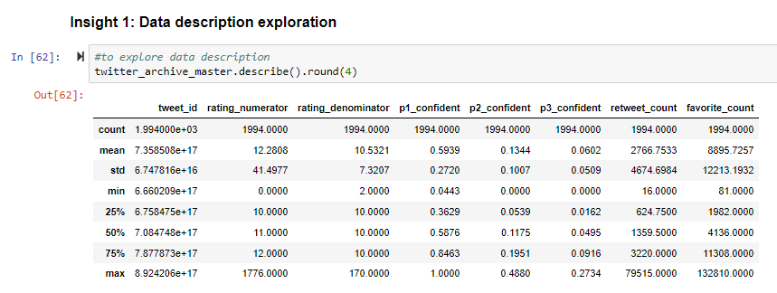

##### From the above data description :

It is observed that;

1. The least and highest `rating denominator` is 2 and 170 respectively, which shows that the WeRateDogs data does not have a uniform rating denominator.
2. From the average value of the `retweet count and favorite count`, it shows that most tweets have favorites than retweets.
3. `p1 confident` has the higest average value while `p3 confident` has the lowest average value.
4. In `p1 - p3 confident` the maximum value ranges between 0 and 1 because they are probabilistic values.

### Insight 2 : Graphical relationship between the retweets, favorites and dog predictions p1-p3

**to show the graphical relation between the variables stated above using the Seaborn pairplot**

Code used:

```
sns.pairplot(twitter_archive_master, vars=["retweet_count", "favorite_count",
                                           "p1_confident" , "p2_confident", "p3_confident"], hue ="dog_stage");
```

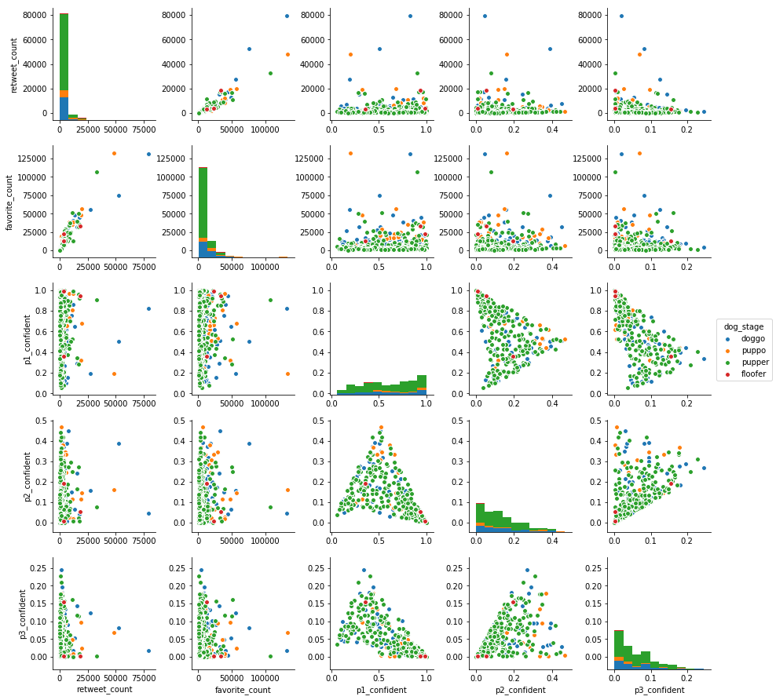

### Insight 3 : Dog-ratio analysis

**to know which dog is the least popular and highest popular stage using value count method**

Code used : `twitter_archive_master.dog_stage.value_counts()` Output:

```
`pupper     223
doggo       72
puppo       28
floofer      3`
```

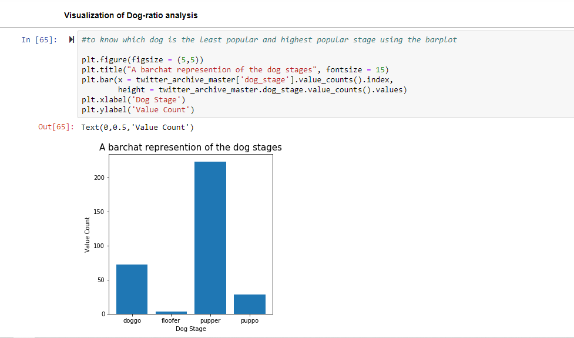

##### From the bar chart plot above:

It is observed that according to decreasing order, the dog stages are; Pupper, Doggo, Puppo and Floofer. Therefore making **Pupper** the most numbered stage and **Floofer** the least number stage.

### Insight 4 : What is the success rate of the algorithm predictions?

**to get the values of each dog prediction using the value.count method**

Code used:

`print(twitter_archive_master.p1_dog.value_counts())

print(twitter_archive_master.p2_dog.value_counts())

print(twitter_archive_master.p3_dog.value_counts())`

Output :

```
True     1477
False     517
Name: p1_dog,
True     1495
False     499
Name: p2_dog,
True     1446
False     548
Name: p3_dog,
```

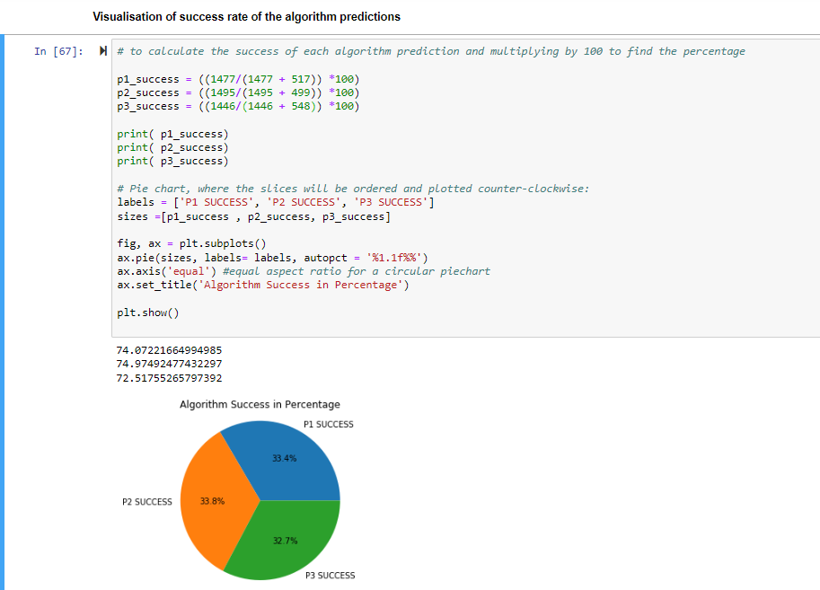

##### From the pie chart above,

It is observed that the three predictions have relatively close algorithm success-rate yet `p2_dog` predicton is the most successful and `p3_dog` prediction* is the least successful. The difference between the prediction success is within the range of (33.8% - 33.4%) = 0.4% and (33.8% - 32.7%) = 1.1%.

### Conclusions

#### General Observation :

1. From the data exploration analysis, it is noted that most tweets are liked than retweeted as `retweet count` has a lower average than `favorite count`.
2. There is a postive correlation between `retweet count and favorite count` feature.
3. In the dog-ratio analysis, *Pupper* the most numbered stage and *Floofer* the least number stage.
4. It is observed that the three predictions have relatively close algorithm success-rate with `p2_dog` predicton is the most successful.

#### Limitation:

1. The unique rating system of WeRateDogs data is an hindrance to carry quality analysis on the dog ratings.
2. The dog_stage variable had alot of NaN data that we could not retrieve from another source or separate dataset.